# Power analysis

Next, we load the function used to simulate power analysis for a single set of parameters and test the function for a set of parameters.

```r
# load the code for simulation experiment 1
source(here::here("functions/sim_power_exp1.R"))
```

```r
# check the timing
tic()

# run the power analysis
power_exp1_test <-
  sim_power_exp1(
    n_sim = 1000,
    alpha_rej = 0.05,
    n_rep = 3,
    sigma_residual = 0.10,
    N_vals = log(c(4, 8, 16, 32, 64)),
    M_vals = c(0, 1),
    P_vals = c(0, 1),
    alpha = 1.5,
    beta1 = 0.2,
    beta2 = -0.12,
    beta3 = 0.05,
    beta4 = 0.05,
    beta5 = 0.05,
    beta6 = 0.05,
    beta7_h0 = 0,
    beta7_ha = 0.10)

# print the results
power_exp1_test
```

```
$type_I_error_rate
[1] 0.048

$type_II_error_rate
[1] 0.518

$power
[1] 0.482
```

```r
# stop the timer
toc()
```

```
4.056 sec elapsed
```

Now we run the power analysis as a background job based. To do this, we first set-up a grid of different parameters based on the previous data and run the simulation for each of these sets of parameters:

```r
# re-run the job
run_power_exp1 <- FALSE

# run the power analysis as a background job
if (run_power_exp1) {
  rstudioapi::jobRunScript(
    path = here::here("01-plan/01-study-design/jobs/run-power-simulations-exp1.R"),
    name = "power-simulations-exp1",
    encoding = "unknown",
    workingDir = NULL,
    importEnv = FALSE,
    exportEnv = "")
}
```

Check the entire output dimensions to see if it ran properly:

```r
# load the power simulations
power_exp1 <- readRDS(here::here("01-plan/01-study-design/jobs/power-simulations-exp1.rds"))

# check the dimensions
dim(power_exp1)
```

```
[1] 51840    14
```

```r
# print the first few rows
head(power_exp1)
```

```
# A tibble: 6 × 14
  n_rep alpha  beta1  beta2  beta3  beta4  beta5  beta6 beta7_ha sigma_residual
  <dbl> <dbl>  <dbl>  <dbl>  <dbl>  <dbl>  <dbl>  <dbl>    <dbl>          <dbl>
1     2 0.405 0.0488 0.0953 -0.105 -0.105 -0.105 -0.105   0.0488            0.1
2     2 0.405 0.0488 0.0953 -0.105 -0.105 -0.105 -0.105   0.0953            0.1
3     2 0.405 0.0488 0.0953 -0.105 -0.105 -0.105 -0.105   0.182             0.1
4     2 0.405 0.0488 0.0953 -0.105 -0.105 -0.105 -0.105   0.262             0.1
5     2 0.405 0.0488 0.0953 -0.105 -0.105 -0.105  0       0.0488            0.1
6     2 0.405 0.0488 0.0953 -0.105 -0.105 -0.105  0       0.0953            0.1
# ℹ 4 more variables: run <int>, type_1_error <dbl>, type_2_error <dbl>,
#   power <dbl>
```

Plot the power curves:

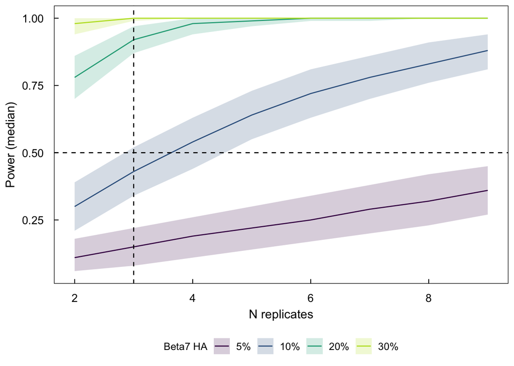

```r
# summarise the data for plotting
power_exp1$beta7_ha_char <- paste0((exp(power_exp1$beta7_ha) - 1)*100, "%")

# relevel
power_exp1$beta7_ha_char <- factor(power_exp1$beta7_ha_char,
                                   levels = c("5%", "10%", "20%", "30%"))

# summarise the data
power_exp1_sum <-
  power_exp1 |>
  dplyr::group_by(sigma_residual, beta7_ha_char, n_rep) |>
  dplyr::summarise(power_med = median(power),
                   quantile_low = quantile(power, 0.025),
                   quantile_high = quantile(power, 0.975))

# recategorise the labels
power_exp1_sum <-
  power_exp1_sum |>
  dplyr::mutate(
    sigma_residual_lab = dplyr::case_when(
      sigma_residual == 0.10 ~ "Residual sd: 0.10",
      sigma_residual == 0.20 ~ "Residual sd: 0.20",
      sigma_residual == 0.30 ~ "Residual sd: 0.30"
    ))

# remove the high residual sd
power_exp1_sum <-
  power_exp1_sum |>
  dplyr::filter(sigma_residual < 0.15)

# plot the data
library(ggplot2)
p1 <-
  ggplot() +
  geom_ribbon(data = power_exp1_sum,
              mapping = aes(x = n_rep,
                            ymin = quantile_low, ymax = quantile_high,
                            fill = beta7_ha_char),
              alpha = 0.2) +
  geom_line(data = power_exp1_sum ,
            mapping = aes(x = n_rep, y = power_med, colour = beta7_ha_char)) +
  geom_hline(yintercept = 0.50, linetype = "dashed") +
  geom_vline(xintercept = 3, linetype = "dashed") +
  labs(colour = "Beta7 HA", fill = "Beta7 HA",) +
  scale_colour_viridis_d(end = 0.9) +
  scale_fill_viridis_d(end = 0.9) +
  xlab("N replicates") +
  ylab("Power (median)") +
  # facet_wrap(~sigma_residual_lab) +
  theme_meta() +
  theme(legend.position = "bottom",
        strip.background = element_blank(),
        strip.text = element_text(colour = "black", size = 12))

# check the graph
p1
```

```r
# save the plot
ggsave(filename = here::here("01-plan/01-study-design/figures-tables/fig-5.png"), p1,
       dpi = 800, width = 5.5, height = 4.5)
```